# Relatório 05 - Teorema do Limite Central - TCL

Alex Gama

12/04/2022

# 1 Objetivo

Demonstrar o TLC;

Simular a Distribuição de Gumbel se aproximando da distribuição NOrmal.

Provar que a distribuição de Gumbel, pode ser convertida em uma distribuição Normal, confirmando o TLC.

# 2 Introdução

A demonstração do Teorema do Limite Central (TLC) utilizando a distribuição de Gumbel pode ser feita numericamente por meio de simulações. A ideia principal é observar como a soma de variáveis aleatórias independentes e identicamente distribuídas provenientes de uma distribuição de Gumbel se aproxima de uma distribuição normal quando o número de somas aumenta.

# 3 Teorema do Limite Central (TLC) com Função Característica, Série de Taylor e Função Geradora

## 3.1 1. Função Característica

A **função característica** de uma variável aleatória $X$ é definida como:
$$\phi_X(t) = \mathbb{E}[e^{itX}],$$
onde $t \in \mathbb{R}$. Ela captura todas as propriedades da distribuição de $X$.

Para a soma padronizada $Z_n = \frac{\sum_{i=1}^n X_i - n\mu}{\sqrt{n}\sigma}$, a função característica é:
$$\phi_{Z_n}(t) = \mathbb{E}\left[e^{itZ_n}\right] = \mathbb{E}\left[e^{it \cdot \frac{1}{\sqrt{n}} \sum_{i=1}^n Y_i}\right],$$
onde $Y_i = \frac{X_i - \mu}{\sigma}$. Como os $Y_i$ são i.i.d., podemos fatorar:
$$\phi_{Z_n}(t) = \left(\phi_Y\left(\frac{t}{\sqrt{n}}\right)\right)^n,$$
onde $\phi_Y(t)$ é a função característica de $Y_i$.

## 3.2 2. Expansão em Série de Taylor

Expandimos $\phi_Y(t)$ em série de Taylor em torno de $t = 0$:
$$\phi_Y(t) = \mathbb{E}[e^{itY}] = 1 + it\mathbb{E}[Y] - \frac{t^2}{2}\mathbb{E}[Y^2] + o(t^2).$$

Como $Y_i$ é padronizada ($\mathbb{E}[Y] = 0$, $\mathbb{E}[Y^2] = 1$):
$$\phi_Y(t) = 1 - \frac{t^2}{2} + o(t^2).$$

Substituímos na expressão para $\phi_{Z_n}(t)$:
$$\phi_{Z_n}(t) = \left(1 - \frac{t^2}{2n} + o\left(\frac{1}{n}\right)\right)^n.$$

## 3.3 3. Aproximação Exponencial

Usamos a aproximação:
$$\left(1 + \frac{x}{n}\right)^n \to e^x, \text{ quando } n \to \infty.$$

Assim:
$$\phi_{Z_n}(t) \to e^{-\frac{t^2}{2}}, \text{ quando } n \to \infty.$$

A função característica $e^{-\frac{t^2}{2}}$ corresponde exatamente à função característica de uma variável normal padrão $\mathcal{N}(0, 1)$. Logo:
$$Z_n \xrightarrow{d} \mathcal{N}(0, 1).$$

## 3.4 4. Relação com a Função Geradora de Momentos

A função geradora de momentos (MGF) $M_X(t)$ de uma variável $X$ está relacionada à função característica:
$$M_X(t) = \phi_X(-it) = \mathbb{E}[e^{tX}].$$

Para somas de variáveis i.i.d., a MGF também combina multiplicativamente. O mesmo raciocínio da expansão em Taylor e aproximação exponencial se aplica. A padronização assegura que a soma converge para a normalidade.

# 4 Demonstrações do Teorema do Limite Central(TLC) e simulações da distribuição de Gumbel

## 4.1 A Distribuição de Gumbel

A **função densidade de probabilidade (PDF)** da distribuição de Gumbel é dada por:
$$f(x) = \frac{1}{\beta} e^{-\frac{x - \mu}{\beta}} e^{-e^{-\frac{x - \mu}{\beta}}},$$
onde:

- $\mu$ é o parâmetro de **localização**,
- $\beta > 0$ é o parâmetro de **escala**.

Nesta demonstração, consideraremos os seguintes valores:

- $\mu = 0$,
- $\beta = 1$.

# 5 Simulação

## 5.1 Passos:

1. Gerar $n$ amostras da distribuição de Gumbel.
2. Calcular a soma de $k$ dessas amostras para diferentes valores de $k$.
3. Padronizar as somas ($Z = \frac{X - \mathbb{E}[X]}{\sigma}$) usando a média ($\mathbb{E}[X]$) e o desvio padrão ($\sigma$) das somas.
4. Comparar o histograma das somas padronizadas com a densidade da distribuição normal padrão.

## 5.2 Código gerador dos gráficos

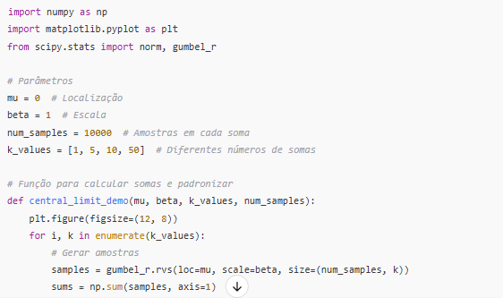

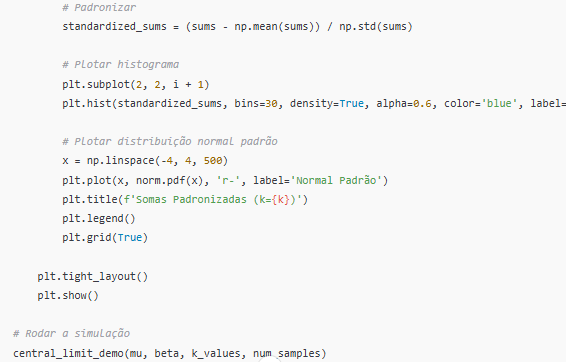

## 5.3 Apresentação dos Gráficos

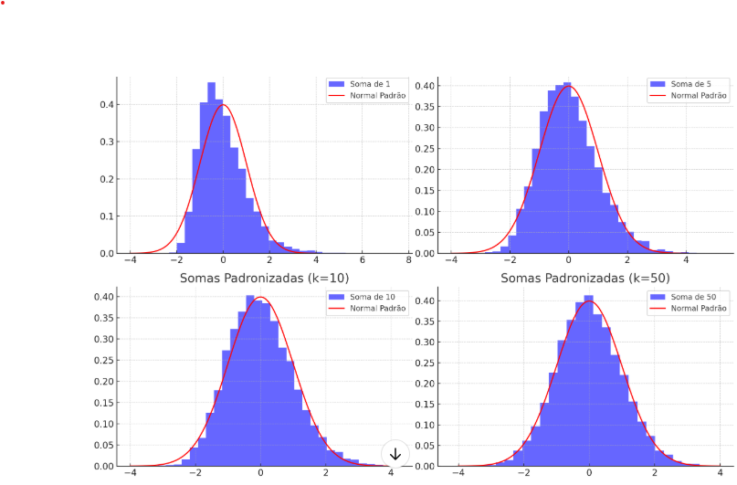

## 5.4 Resultados

A partir da análise dos gráficos que mostraram os resultados da simulação do Teorema do Limite Central usando a distribuição de Gumbel foi possível observar que com o aumento de k, o histograma das somas padronizadas se aproxima da curva da distribuição normal padrão (linha vermelha). Isso ilustra o comportamento previsto pelo TLC, mesmo para distribuições assimétricas como a de Gumbel.

# 6 Conclusões:

A combinação da **função característica**, a **expansão de Taylor** e a **função geradora de momentos** permite demonstrar o TLC. A chave está no comportamento assintótico da função característica das somas padronizadas, que converge para a função característica da normal padrão $\mathcal{N}(0, 1)$.

Por meio dessa simulação, observamos que mesmo para uma distribuição assimétrica como a de Gumbel, a soma de variáveis aleatórias tende a uma distribuição normal conforme o número de variáveis aumenta, validando o Teorema do Limite Central.